# CodingNotesMarkdown

Madelynn VanderHoek

2026-02-15

- YAML header will be in html in defelt that is good at viewing in a web browser but no on github
- This in the output section of the YAML header will be good for looking at the document on github ouput: md_document: variant: gfm word_document: html:document

KNITTING - when you select knit a document togther and there are no errors in the code you can generate an html doucment, a word document, and/or a .md document.

R MARKDOWN AND CODE CHUNCKS - To include r code into your Rmarkdown documnet you will need to insert a code chuck.

```r
# we can set chucks to show up in the resulting document by setting some options like- {r setup, include=TRUE}
```

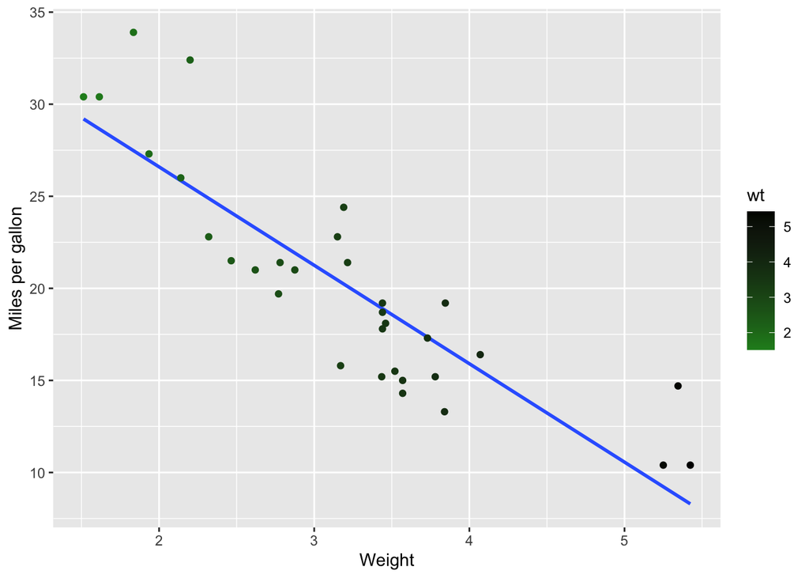

```r
# we can include code and plots into the code chucks

library(knitr)
library(ggplot2)
library(rmarkdown)

data("mtcars")
ggplot(mtcars, aes(x = wt, y = mpg)) +
  geom_smooth(method = lm, se = FALSE) +
  geom_point(aes(color = wt)) +
  xlab("Weight") +
  ylab("Miles per gallon") +
  scale_color_gradient(low = "forestgreen", high = "black")
```

R MARKDOWN FORMATTING OPTIONS # First-level header ## Second-level header ### Third-level header - this allows different text sizes

You can do nutiple types of bullet-points - text - text

1. text
- text
2. text

italic text ‘*ltalic*’ bold text ‘**bold**’

#Blockquotes are writtien after > > “I thoroughly disapprove of duels. If a man should challenge me, I would take him kindly and forgivigly by the hand and lead him to a quiet place and kill him.” > > — Mark Twain

LINKS https://agriculture.auburn.edu/about/directory/faculty/zachary-noel/ https://agriculture.auburn.edu/about/directory/faculty/zachary-noel/ [Noel Lab](https://agriculture.auburn.edu/about/directory/faculty/zachary-noel/)

IMAGES _ you can embed images into the output. You will provide a file path to the images from the current rmd file. For ease just put the file in the smae direcotry as your rmd file. - if your forget the (!), it will become just a link

```r
#![shrek and ggplot](IMG_8889-Copy.jpg)
```

```r
kable(head(mtcars, n = 5), digits = 3, format = "markdown")
```

|  | mpg | cyl | disp | hp | drat | wt | qsec | vs | am | gear | carb |
| --- | --- | --- | --- | --- | --- | --- | --- | --- | --- | --- | --- |
| Mazda RX4 | 21.0 | 6 | 160 | 110 | 3.90 | 2.620 | 16.46 | 0 | 1 | 4 | 4 |
| Mazda RX4 Wag | 21.0 | 6 | 160 | 110 | 3.90 | 2.875 | 17.02 | 0 | 1 | 4 | 4 |
| Datsun 710 | 22.8 | 4 | 108 | 93 | 3.85 | 2.320 | 18.61 | 1 | 1 | 4 | 1 |
| Hornet 4 Drive | 21.4 | 6 | 258 | 110 | 3.08 | 3.215 | 19.44 | 1 | 0 | 3 | 1 |
| Hornet Sportabout | 18.7 | 8 | 360 | 175 | 3.15 | 3.440 | 17.02 | 0 | 0 | 3 | 2 |

When you click the ‘**knit**’, it will render the document using the existing syntax

Rmarkdown is not necessary for full reproducibility, but it does ensure that someone downloading your code from github can understand what you are talking about.